# Final Project: Austin Animal Center Analysis

- Show All Code
- Hide All Code
- View Source

Author

Anjelica Martinez

Published

August 20, 2025

[figure not shown]

Illustration by Sara Oliveira (Unsplash+)

# Shelter Stories in the Data

## An analysis of the Austin Animal Center (AAC) intake and outcomes dataset

For this project, I used the [Austin Animal Center (AAC) dataset](https://data.austintexas.gov/browse?q=animal&sortBy=relevance&page=1&pageSize=20), which comes from the [City of Austin’s open data portal](https://data.austintexas.gov/). Each row represents a single animal and its outcome: adoption, transfer, euthanasia, or return-to-owner. Alongside that outcome, the dataset records things like species, breed, age at intake, sex, and intake type. Every row represents one shelter animal’s visit to the center, a piece of their story.

The dataset spans from mid-2013 through mid-2025 and includes over 130,000 animals. Dogs and cats make up the overwhelming majority thought you’ll also see the occasional bat, racoon or chicken sneaking into the records. The breadth of the data makes it perfect for exploring questions about shelter operations, adoption patterns, and the uncomfortable but important reality of euthanasia.

Rather than trying to explore every variable, I focused on the ones that get at meaningful shelter outcomes: how long animals stay at the shelter, what factors affect their likelihood of being adopted, and how these patterns vary across species, breeds, and age groups. These are the kinds of questions that matter for shelter policy, for adopters, and ultimately for the animals themselves.

## Part 0: Preparing the Data for Analysis

Before I could dig into the fun part of finding patterns, I had to wrestle with the less glamorous side of data science: cleaning. The Austin Animal Center’s intake and outcome datasets are incredibly detailed and updated every single day, which is a goldmine for analysis. But like most real world data, it comes with quirks. Some dates are off, columns don’t always line up, and a few values just don’t make sense. So, before chasing insights, I had to make sure the foundation was solid.

### Step 1: Cleaning Up the Outcomes Data

I started with the **outcomes dataset**, which tracks how each animal leaves the shelter, whether through adoption, return to owner, transfer, or unfortunately, euthanasia. It also includes details like breed, sex, and age, making it a rich starting point for understanding patterns.

The first order of business was good old housekeeping!

- Standardize column names so they play nicely with R.
- Replace blank strings with proper `NA` values *(so missing data is clearly missing, easier for analysis later)*
- Convert all the date columns into actual date-time objects instead of text

This setup step may not sound exciting, but it’s the backbone of everything that comes next. Without it, any patterns I found later could have been misleading or completely wrong!

```r
# Read in the Austin Animal Center Animal Outcomes dataset.
aac_outcome <- read.csv(here("Data", "aac_outcomes.csv"))

# Clean up column names
aac_outcome <- aac_outcome |>
  clean_names() |>
  mutate(across(everything(), ~ na_if(.x, "")))

# Change date types for columns date_of_birth and date_time
# - Separate month_year to two separate month and year columns
aac_outcome <- aac_outcome |>
  mutate(
    date_of_birth = ymd(date_of_birth),
    date_time = ymd_hms(date_time),
    year = year(date_time),
    month = month(date_time)
  ) |>
  select(-month_year)
```

### Step 2: Fixing Impossible Ages

**Age** is usually a key piece of the puzzle in shelter research, so I checked how old each dog was when they left the shelter. That’s when I spotted something weird: a handful of dogs had negative ages. What in the world? After some digging, I notied that some of these pup’s date of birth’s came *after* the date they left the shelter. This must be a data entry error.

To fix it, I:

- Calculated each dog’s age in days and years.
- Flagged any cases where the birth date was in the future.
- Re-coded those impossible ages as incorrect so they could be filtered out and prevent skewing later results.

Even though age didn’t end up being the main focus of my project (the data had other more interesting stories to tell), cleaning it now means the dataset is ready for me (or anyone else) to dig into any age-related patterns in the future without running into sci-fi dogs. (You’re welcome.)

```r
# Calculate true ages of animals ------------------------------------
# - separating into two columns for:
# -- age in years
# -- age in days
aac_outcome <- aac_outcome |>
  mutate(
    age_days = as.numeric(
      difftime(date_time, date_of_birth, units = "days")
    ),
    age_years = age_days / 365.25
  )

# Mark observations that have negative values for their ages
aac_outcome <- aac_outcome |>
  mutate(
    invalid_dob = if_else(date_of_birth > date_time, TRUE, FALSE),
    age_days = if_else(invalid_dob, NA_real_, age_days),
    age_years = if_else(invalid_dob, NA_real_, age_years)
  )

# Rename the column names for easier identification
aac_outcome <- aac_outcome |>
  rename(
    dob = date_of_birth,
    outcome_datetime = date_time,
    sex_at_outcome = sex_upon_outcome,
    reported_age = age_upon_outcome,
    species = animal_type,
    outcome_year = year,
    outcome_month = month,
    calculated_age_days = age_days,
    calculated_age_years = age_years,
    dob_error_flag = invalid_dob
  )
```

### Step 3: Cleaning the Intake Data

The intake dataset tells the “arrival story” for each animal, whether they came in as a stray, were surrendered by an owner, or showed up some other way. I gave this dataset the same treatment as the outcomes data: standardized the column names, fixed the date formats, and split the reported age into a clean numeric value plus its unit (days, months, or years).

```r
# Read in intake dataset
aac_intake <- read.csv(here("Data", "aac_intakes.csv"))

# Clean up column names
aac_intake <- aac_intake |>
  clean_names()

# Change date types for columns date_of_birth and date_time
# - Separate month_year to two seperate month and year columns
aac_intake <- aac_intake |>
  mutate(
    datetime_intake = mdy_hms(date_time),
    year_intake = year(datetime_intake),
    month_intake = month(datetime_intake)
  ) |>
  select(-month_year)
```

### Step 4: Fixing the Reported Age

One of the quirks in the intake dataset was how age was recorded. Instead of a clean number, it came in as text strings like “3 years” or “8 months.” That might make sense for staff typing quickly, but it’s a nightmare if you want to run calculations.

To fix it, I split the age into two parts:

- A numeric value (the actual number)
- A time unit (days, weeks, months, or years)

That way, I could easily convert everything into days or years when I needed to compare across animals. It’s a small step, but without it, the math later would’ve been messy or worse, wrong.

```r
# Reported Age ----------------------------------------------------------
# - separate numeral and length type (years/months)
# - calculate age in days instead

# Builds a lookup table that converts each unit to days
age_lookup <- tibble(
  unit_raw = c(
    "day", "days",
    "week", "weeks",
    "month", "months",
    "year", "years"
  ),
  to_days = c(
    1, 1,
    7, 7,
    30.44, 30.44,
    365.25, 365.25
  )
)

# Parses the text column, joins the lookup, and calculates days
aac_intake <- aac_intake |>
  separate(age_upon_intake,
    into = c("age_val", "age_unit"),
    sep = "\\s+",
    remove = FALSE
  ) |>
  mutate(age_val = as.numeric(age_val)) |>
  left_join(age_lookup, by = c("age_unit" = "unit_raw")) |>
  mutate(
    age_days_intake = age_val * to_days,
    age_years_intake = age_days_intake / 365.25
  )
```

### Step 5: Fixing Missing Names

Not every dog in the dataset had a name. Sometimes the shelter just leaves it blank, which technically shows up as an empty string instead of a true missing value. That can cause problems if R thinks “” is an actual name.

To clean this up, I recoded those blanks as proper missing values (`NA`). It’s a small fix, but it’s better to clearly mark “unknown” than to accidentally count a bunch of nameless dogs as having the same weird non-name!

```r
# Change missing names in name column from empty to NA
aac_intake <- aac_intake |>
  mutate(name = na_if(str_squish(name), ""))
```

### Step 6: Matching Intakes and Outcomes

Because many animals come to the shelter more than once, I needed a reliable way to connect the right intake record with the right outcome record. To do this, I gave each visit a “stay number” and then joined the intake and outcome datasets using both the animal’s ID and their stay number.

From there, I filtered the data down to dogs and pulled out the ones with multiple visits. These repeat visitors became the heart of my analysis. I chose to focus only on dogs, since trying to analyze repeat visits across every species at the shelter would’ve been far too messy (and probably a project of its own).

With the data cleaned, fixed, and matched, I finally had a dataset I could work with. Each visit lined up with the right outcome. From here, I could actually start digging into the fun part: exploring the patterns in which dogs come back to the shelter and what happens to them next!

```r
# Tags each stay in date order for both intake and outcome dataframes
aac_intake <- aac_intake |>
  arrange(animal_id, datetime_intake) |>
  group_by(animal_id) |>
  mutate(stay_n = row_number()) |>
  ungroup()

aac_outcome <- aac_outcome |>
  arrange(animal_id, outcome_datetime) |>
  group_by(animal_id) |>
  mutate(stay_n = row_number()) |>
  ungroup()

# Joins the two columns by animal id and stay_n
aac_stays <- aac_intake |>
  left_join(aac_outcome,
    by = c("animal_id", "stay_n"),
    suffix = c("_in", "_out")
  )

# Create separate dataframe for just dogs
dogs <- aac_stays |>
  filter(animal_type %in% "Dog")

# Create a dataframe with a list of each animal-id and the number of total
# visits they've had
repeat_ids <- dogs |>
  group_by(animal_id) |>
  summarise(n_intakes = n(), .groups = "drop") |>
  filter(n_intakes > 1)

# Combine above dataframes to create one dataframe of only repeat dogs
dog_repeat <- dogs |>
  semi_join(repeat_ids, by = "animal_id")
```

## Part 1: All Repeat Dogs — First Look at the Numbers

Before diving into detailed patterns, I wanted to get a sense of the big picture: what do dogs who return to the shelter more than once actually look like as a group?

Across all repeat visitors, the number of stays ranged from just two to a jaw-dropping **33** visits (more on him later).

Most dogs didn’t hit such extremes. On average, a repeat visitor came back about 2.3 times, with the bulk clustering around two or three stays. Ages ran the full spectrum, from a few-day-old puppies to seniors pushing 20, though the average was about 3 years old.

Breed patterns stood out quickly. **Pit Bull Mixes** **topped the list**, followed by Labrador Retriever Mixes and other familiar companion breeds. On the sex side, suprinsingly **neutered males** were the single largest group, even though being fixed is supposed to reduce certain return risks (or so you’d think).

These broad strokes already pointed to two paths worth following:

- Are certain breeds facing bigger barriers to staying in homes?
- And why are neutered males (typically considered lower-risk) so over represented among repeat visitors?

**Note**

**Note:** These numbers come after cleaning and matching intake and outcome records, removing any impossible (negative number) ages. Descriptive stats (range, mean, median, standard deviation) plus frequency counts for breed, sex, intake type, and condition gave this first snapshot.

```r
# Functions for Statistical Summaries --------------------------------------
# Creates function to provide categorical summary statistics
cat_stat <- function(x) {
  if (!is.character(x) && !is.factor(x)) {
    stop(
      "This function only works for categorical (character or factor) vectors."
    )
  }

  freq_table <- table(x, useNA = "ifany")
  top_level <- names(freq_table)[which.max(freq_table)]
  top_count <- max(freq_table, na.rm = TRUE)
  top_prop <- round(top_count / sum(freq_table), 3)

  tibble(
    n = length(x),
    n_na = sum(is.na(x)),
    n_unique = n_distinct(x),
    most_common = top_level,
    most_common_n = top_count,
    most_common_prop = top_prop
  )
}

# Creates a function that runs numeric summary statistics
sum_stat <- function(x) {
  if (!is.numeric(x)) {
    stop("This function only works for numeric vectors.")
  }

  tibble(
    range = str_c(min(x, na.rm = TRUE),
      max(x, na.rm = TRUE),
      sep = " - "
    ),
    mean = mean(x, na.rm = TRUE),
    median = median(x, na.rm = TRUE),
    sd = sd(x, na.rm = TRUE),
    n_na = sum(is.na(x)),
    n_unique = n_distinct(x)
  )
}

# Summary Statistics Calculations ----------------------------------

# Summary statistics of age of dogs with repeat intakes
num_stats_dogs <- dog_repeat |>
  select(calculated_age_years) |>
  map_dfr(sum_stat, .id = "column")

# Summary statistics of the number of times a dog returned to the center
## I used a separate dataframe with only a total of the number of visits per
## animal id to run this calculation
repeat_ids |>
  select(n_intakes) |>
  map_dfr(sum_stat, .id = "column")
```

```
# A tibble: 1 × 7
  column    range   mean median    sd  n_na n_unique
  <chr>     <chr>  <dbl>  <dbl> <dbl> <int>    <int>
1 n_intakes 2 - 33  2.35      2 0.845     0       13
```

```r
# Summary statistics for different categories
cat_stats_dogs <- dog_repeat |>
  select(animal_id, breed_in, sex_upon_intake, intake_type, intake_condition) |>
  map_dfr(cat_stat, .id = "column")

# Reviews both summaries
num_stats_dogs # numeric
```

```
# A tibble: 1 × 7
  column               range                    mean median    sd  n_na n_unique
  <chr>                <chr>                   <dbl>  <dbl> <dbl> <int>    <int>
1 calculated_age_years 0.00391664765381398 - …  3.01   2.07  2.80    99    24094
```

```r
cat_stats_dogs # categorical
```

```
# A tibble: 5 × 7
  column             n  n_na n_unique most_common most_common_n most_common_prop
  <chr>          <int> <int>    <int> <chr>               <int>            <dbl>
1 animal_id      25057     0    10660 A721033                33            0.001
2 breed_in       25057     0      995 Pit Bull M…          3906            0.156
3 sex_upon_inta… 25057     0        5 Neutered M…          8668            0.346
4 intake_type    25057     0        5 Stray               13471            0.538
5 intake_condit… 25057     0       15 Normal              23691            0.945
```

### 1. How Many Times Do Dogs Return to the Shelter?

The real outliers were rare. Just 109 dogs cycled through six to nine stays, and only six dogs crossed the double-digit mark.

And then there’s the record-holder: one dog with 33 separate stays. That number is so far off the chart it immediately begged for a closer look. Which is exactly what I did next!

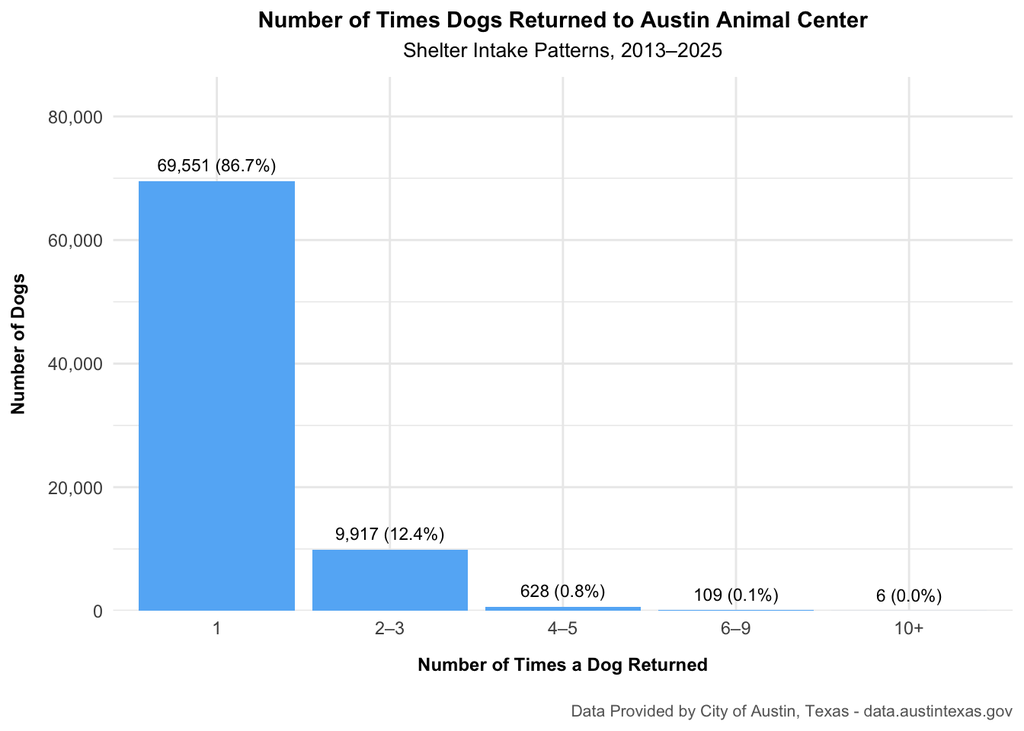

Data Provided by City of Austin, Texas - data.austintexas.gov

```r
# Summarize how many animals had each return count
return_freq <- dogs |>
  group_by(animal_id) |>
  summarise(n_intakes = n(), .groups = "drop")

# Bin the times returned
repeat_bins <- return_freq |>
  mutate(
    bin = case_when(
      n_intakes == 0 ~ "0",
      n_intakes == 1 ~ "1",
      n_intakes %in% 2:3 ~ "2–3",
      n_intakes %in% 4:5 ~ "4–5",
      n_intakes %in% 6:9 ~ "6–9",
      n_intakes >= 10 ~ "10+"
    ),
    bin = factor(bin, levels = c("0", "1", "2–3", "4–5", "6–9", "10+"))
  ) |>
  count(bin, name = "dogs") |>
  mutate(pct = dogs / sum(dogs))

# Plot the results
ggplot(repeat_bins, aes(x = bin, y = dogs)) +
  geom_col(fill = "#64B5F6") +
  geom_text(aes(label = paste0(comma(dogs), " (", percent(pct, 0.1), ")")),
    vjust = -.8, size = 3
  ) +
  labs(
    title = "Number of Times Dogs Returned to Austin Animal Center",
    subtitle = "Shelter Intake Patterns, 2013–2025",
    x = "Number of Times a Dog Returned",
    y = "Number of Dogs",
    caption = "Data Provided by City of Austin, Texas - data.austintexas.gov"
  ) +
  scale_y_continuous(
    labels = comma,
    expand = expansion(mult = c(0, 0.08)),
    limits = c(0, 80000) # extend y-axis
  ) +
  theme_minimal() +
  theme(
    plot.title = element_text(
      hjust = 0.5, face = "bold", size = 11,
      margin = margin(b = 5) # add space below title
    ),
    plot.subtitle = element_text(
      hjust = 0.5,
      size = 10,
      margin = margin(b = 8)
    ),
    plot.caption = element_text(
      hjust = 1,
      size = 8,
      color = "gray40",
      margin = margin(t = 15)
    ),
    axis.title.x = element_text(
      margin = margin(t = 10), face = "bold", size = 9
    ),
    axis.title.y = element_text(
      margin = margin(r = 10), face = "bold", size = 9
    )
  )
```

### Snapshot: Lil’ Bit – The Dog With 33 Returns

While most dogs only returned once, a handful became repeat offenders. The most extreme? Lil’ Bit, the Jack Russell with the undisputed record-holder with 33 stays.

Most gaps between visits were short, just a few days or weeks. The median time between stays was about 23.3 days (orange dashed line on the second chart), suggesting a repeating cycle: Lil’ Bit slipped out, ended up at the shelter, and was quickly reclaimed.

But there were exceptions. At one point, he managed nearly a year at home (~350 days, marked in green) before diving right back into his old routine. His earliest intakes were listed as “stray,” but later ones were usually “Public Assist,” meaning neighbors or community members brought him in.

The chart makes his story clear: each point is both a homecoming and a farewell. His owner always came back for him, but the sheer repetition points to an unsolved problem, whether containment, training, or just one dog’s Houdini-level skills.

Lil’ Bit’s saga is rare, but it sets the stage for a bigger question: are certain breeds more likely to become repeat visitors?

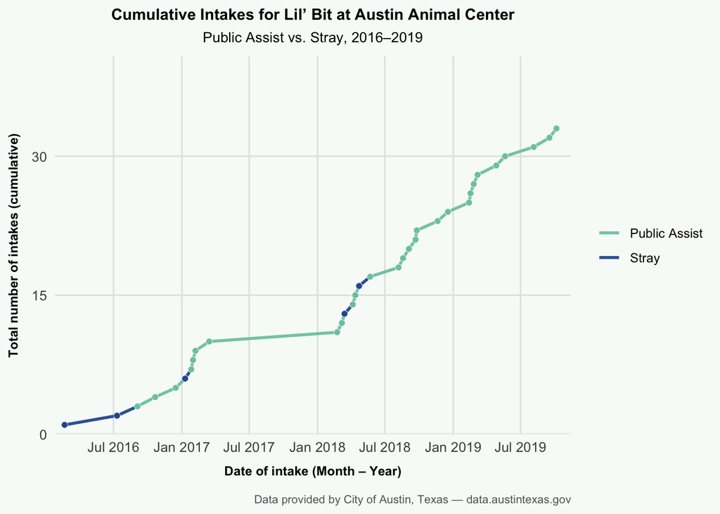

Data Provided by City of Austin, Texas - data.austintexas.gov

```r
# Find the dog with the most returns (Lil' Bit)
top_dog_id <- return_freq |>
  arrange(desc(n_intakes)) |>
  slice(1) |>
  pull(animal_id)

# Build Lil’ Bit’s history
lil_bit <- aac_stays |>
  filter(animal_id == top_dog_id) |>
  arrange(datetime_intake) |>
  mutate(
    datetime_intake = as_datetime(datetime_intake),
    outcome_datetime = as_datetime(outcome_datetime),
    stay_n = row_number(),
    days_between = as.numeric(
      difftime(datetime_intake, lag(datetime_intake), units = "days")
    )
  ) |>
  select(
    stay_n, datetime_intake, intake_type, age_upon_intake,
    outcome_datetime, outcome_type, outcome_subtype, reported_age, days_between
  )

# Plots a cumulative timeline for Lil' Bit
ggplot(lil_bit, aes(
  x = datetime_intake, y = stay_n, group = 1, color = intake_type
)) +
  geom_line(linewidth = 1, alpha = 0.95) +
  geom_point(aes(fill = intake_type),
    shape = 21, size = 2, stroke = 0.2, color = "white"
  ) +
  scale_color_manual(values = c(
    "Public Assist" = "#7CC8AE",
    "Stray"         = "#2C5AA0"
  )) +
  scale_fill_manual(values = c(
    "Public Assist" = "#7CC8AE",
    "Stray"         = "#2C5AA0"
  ), guide = "none") +

  # nice date labels
  scale_x_datetime(
    date_breaks = "6 months",
    date_labels = "%b %Y",
    expand = expansion(mult = c(0.02, 0.03))
  ) +
  scale_y_continuous(
    limits = c(0, 40),
    breaks = seq(0, 40, 15),
    expand = expansion(mult = c(0, 0.02))
  ) +
  labs(
    title = "Cumulative Intakes for Lil’ Bit at Austin Animal Center",
    subtitle = "Public Assist vs. Stray, 2016–2019",
    x = "Date of intake (Month – Year)",
    y = "Total number of intakes (cumulative)",
    caption = "Data provided by City of Austin, Texas — data.austintexas.gov",
    color = NULL
  ) +
  theme_minimal(base_size = 12) +
  theme(
    panel.background = element_rect(fill = "#F8FBF9", color = NA),
    plot.background = element_rect(fill = "#F8FBF9", color = NA),
    panel.grid.major = element_line(color = "gray90"),
    panel.grid.minor = element_blank(),
    plot.title = element_text(hjust = 0.5, face = "bold", size = 11),
    plot.subtitle = element_text(
      hjust = 0.5, size = 10, margin = margin(b = 8)
    ),
    axis.title.x = element_text(
      margin = margin(t = 8), face = "bold", size = 9
    ),
    axis.title.y = element_text(
      margin = margin(r = 8), face = "bold", size = 9
    ),
    plot.caption = element_text(
      hjust = 1, size = 8, color = "gray40", margin = margin(t = 12)
    ),
    legend.position = "right",
    legend.text = element_text(size = 9)
  )
```

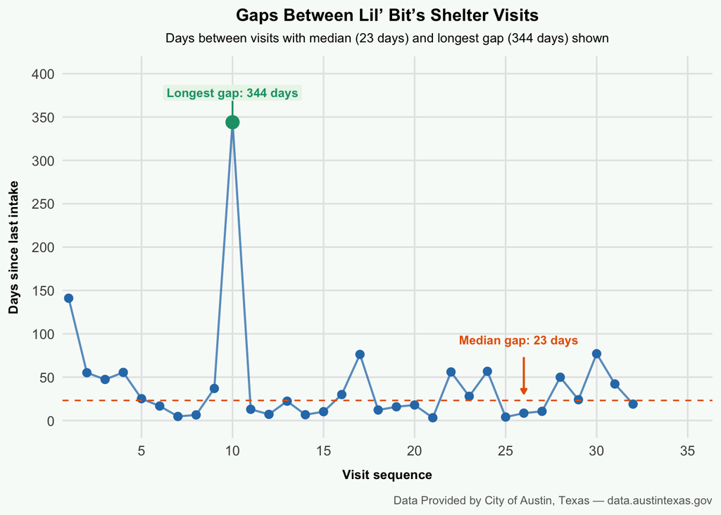

Source: Data Provided by City of Austin, Texas - data.austintexas.gov

```r
# Create cleaned gap dataset:
# - remove rows with missing values in days_between
# - assign a visit sequence index (stay_ix) to each record
gap_df <- lil_bit |>
  dplyr::filter(!is.na(days_between)) |>
  dplyr::mutate(stay_ix = dplyr::row_number())

# Calculate key summary values for plotting:
# - median gap between visits
# - index and details of the longest gap
# - total number of visits (for axis scaling)
median_gap  <- median(gap_df$days_between, na.rm = TRUE)
long_idx    <- which.max(gap_df$days_between)
long_point  <- gap_df[long_idx, ]
n_visits    <- max(gap_df$stay_ix, na.rm = TRUE)

# Define custom colors, background, and axis ranges
col_line   <- "#2C7BB6"   # deep blue for series
col_long   <- "#1B9E77"   # green for longest gap
col_median <- "#E66101"   # orange for median line/text
bg_fill    <- "#F8FBF9"
y_lim      <- c(0, 400)   # lock y-axis as you set
x_max      <- 35          # forces x-axis to end at 40

# Plot gaps between Lil’ Bit’s shelter visits:
# - Line + points show days between each visit
# - Highlight the longest gap with a label and marker
# - Add dashed horizontal line for median gap
# - Customize axes, labels, title, and theme
ggplot(gap_df, aes(x = stay_ix, y = days_between)) +
  geom_line(color = col_line, linewidth = 0.7, alpha = 0.75) +
  geom_point(color = col_line, size = 2.4) +
  geom_point(
    data = long_point,
    aes(x = stay_ix, y = days_between),
    color = col_long, size = 4
  ) +
  annotate("segment",
    x = long_point$stay_ix, y = long_point$days_between + 2,
    xend = long_point$stay_ix, yend = long_point$days_between + 28,
    color = col_long, linewidth = 0.6
  ) +
  annotate("label",
    x = long_point$stay_ix, y = long_point$days_between + 34,
    label = paste0(
      "Longest gap: ", round(long_point$days_between), " days"
    ),
    color = col_long, fill = "#EAF6EA", label.size = 0,
    size = 3, fontface = "bold"
  ) +
  geom_hline(
    yintercept = median_gap, linetype = "dashed",
    color = col_median, linewidth = 0.5
  ) +
  annotate("text",
    x = x_max - 6, y = median_gap + 70,
    label = paste0("Median gap: ", round(median_gap), " days"),
    color = col_median, size = 3, fontface = "bold", hjust = 1
  ) +
  annotate("segment",
    x = x_max - 9, y = median_gap + 50,
    xend = x_max - 9, yend = median_gap + 8,
    color = col_median, linewidth = 0.7,
    arrow = arrow(length = unit(0.05, "in"), type = "closed")
  ) +
  scale_x_continuous(
    limits = c(1, x_max),
    breaks = seq(0, x_max, by = 5),
    expand = expansion(mult = c(0.01, 0.04))
  ) +
  scale_y_continuous(
    limits = y_lim,
    breaks = scales::pretty_breaks(n = 8)
  ) +
  labs(
    title = "Gaps Between Lil’ Bit’s Shelter Visits",
    subtitle = paste0(
      "Days between visits with median (23 days) and longest gap (344 days)",
      " shown"),
    x = "Visit sequence",
    y = "Days since last intake",
    caption = "Data Provided by City of Austin, Texas — data.austintexas.gov"
  ) +
  coord_cartesian(clip = "off") +
  theme_minimal(base_size = 12) +
  theme(
    panel.background = element_rect(fill = bg_fill, color = NA),
    plot.background = element_rect(fill = bg_fill, color = NA),
    panel.grid.major = element_line(color = "gray90"),
    panel.grid.minor = element_blank(),
    plot.title = element_text(hjust = 0.5, face = "bold", size = 12),
    plot.subtitle = element_text(
      hjust = 0.5, size = 9,
      margin = margin(b = 8)
    ),
    axis.title.x = element_text(
      margin = margin(t = 8), face = "bold",
      size = 9
    ),
    axis.title.y = element_text(
      margin = margin(r = 8), face = "bold",
      size = 9
    ),
    plot.caption = element_text(
      size = 8, color = "gray40", hjust = 1,
      margin = margin(t = 10)
    )
  )
```

### 2. Most Common Dog Breeds Returning to the Shelter

This doesn’t seem to be just about breed popularity in Austin. The pattern could reflect deeper challenges:

- Housing and insurance restrictions that limit where certain breeds can live.
- Behavioral traits that require more training than many adopters anticipate.
- Mismatches between dogs and households that only become obvious after the honeymoon period ends.

The data doesn’t tell us the “why” outright, but it does point us toward where to look. If the goal is to cut down repeat returns, these breeds are the logical starting point for targeted outreach, training support, and adoption counseling.

Of course, breed is just one part of the story. Another angle worth exploring is **sex,** not just male versus female, but whether the dogs were intact or already fixed.

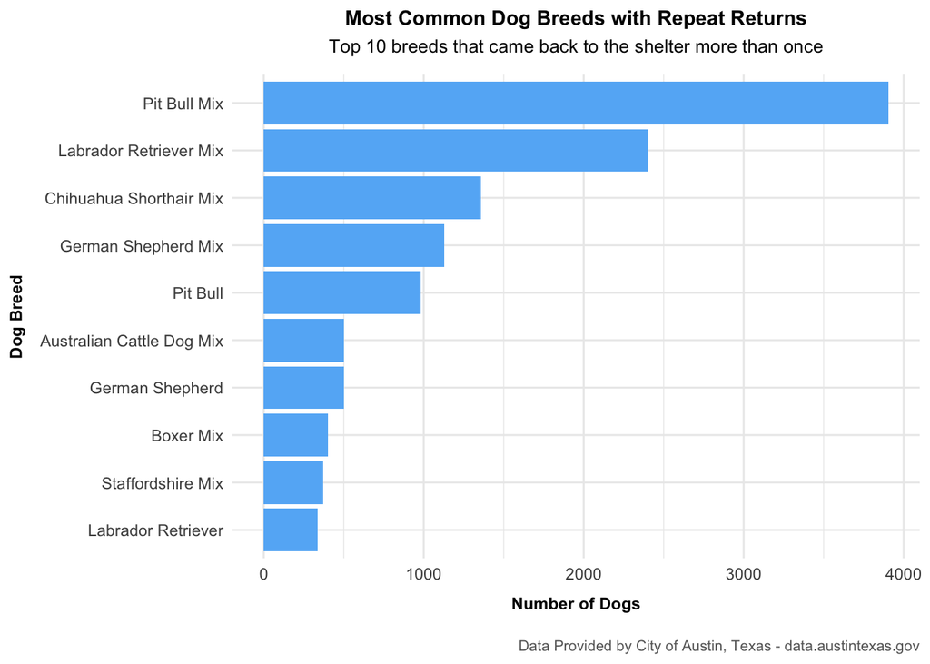

Source: Source: City of Austin, Texas - data.austintexas.gov

```r
# Finds out what the top 10 dog breeds are
dog_repeat |>
  count(breed_in) |>
  slice_max(n, n = 10) |>
  ggplot(aes(x = fct_reorder(breed_in, n), y = n)) +
  geom_col(fill = "#64B5F6") +
  coord_flip() +
  labs(
    title = "Most Common Dog Breeds with Repeat Returns",
    subtitle = "Top 10 breeds that came back to the shelter more than once",
    x = "Dog Breed",
    y = "Number of Dogs",
    caption = "Data Provided by City of Austin, Texas - data.austintexas.gov"
  ) +
  theme_minimal() +
  theme(
    plot.title = element_text(hjust = 0.5, face = "bold", size = 11),
    plot.subtitle = element_text(
      hjust = 0.5, margin = margin(b = 10),
      size = 10
    ),
    axis.title.x = element_text(
      margin = margin(t = 8), size = 9, face = "bold"),
    axis.title.y = element_text(
      margin = margin(r = 8), size = 9, face = "bold"),
    plot.caption = element_text(
      hjust = 1,
      size = 8,
      color = "gray40",
      margin = margin(t = 15)
    ),
    legend.title = element_text(face = "bold", size = 8),
    legend.text = element_text(size = 8),
    legend.key.size = unit(1, "lines"),
    legend.spacing.y = unit(0.5, "cm")
  )
```

### 3. Sex and Spay/Neuter Status of Repeat-Return Dogs

When we imagine dogs that keep ending up back at the shelter, the stereotype is usually of intact males roaming the neighborhood looking for a mate. But the numbers tell a different story.

That’s important because it pushes back against a long-standing assumption in sheltering: that mating behavior is the main driver of repeat returns. The data suggests otherwise. Issues like behavior, housing restrictions, or sudden changes in an owner’s life are more likely culprits.

In other words, fixing the animal doesn’t necessarily address the problem.

So far, we’ve looked at who these repeat dogs are. Next, I turned to when they tend to return, to see if any seasonal or historical patterns stood out.

```r
# Creates a dataframe with the counts of male vs female dogs as well as their proportions of intact vs fixed status
dog_repeat_sex <- dog_repeat |>
  mutate(
    SexSimple = case_when(
      sex_upon_intake %in% c("Intact Male", "Neutered Male") ~ "Male",
      sex_upon_intake %in% c("Intact Female", "Spayed Female") ~ "Female",
      TRUE ~ "Unknown"
    ),
    FixStatus = case_when(
      sex_upon_intake %in% c("Intact Male", "Intact Female") ~ "Intact",
      sex_upon_intake %in% c("Neutered Male", "Spayed Female") ~ "Fixed",
      TRUE ~ "Unknown"
    )
  ) |>
  filter(SexSimple != "Unknown", FixStatus != "Unknown") |>
  count(SexSimple, FixStatus) |>
  group_by(SexSimple) |>
  mutate(
    total_sex = sum(n),
    pct_within_sex = n / total_sex,
    label = percent(pct_within_sex, accuracy = 0.1)
  ) |>
  ungroup() |>
  mutate(SexSimple = factor(SexSimple,
    levels = names(sort(tapply(total_sex, SexSimple, max), decreasing = TRUE))
  ))

# Review the table of counts for male vs female and the proportion of intact vs
# fixed
dog_repeat_sex
```

```
# A tibble: 4 × 6
  SexSimple FixStatus     n total_sex pct_within_sex label
  <fct>     <chr>     <int>     <int>          <dbl> <chr>
1 Female    Fixed      6598     10637          0.620 62.0%
2 Female    Intact     4039     10637          0.380 38.0%
3 Male      Fixed      8668     14413          0.601 60.1%
4 Male      Intact     5745     14413          0.399 39.9%
```

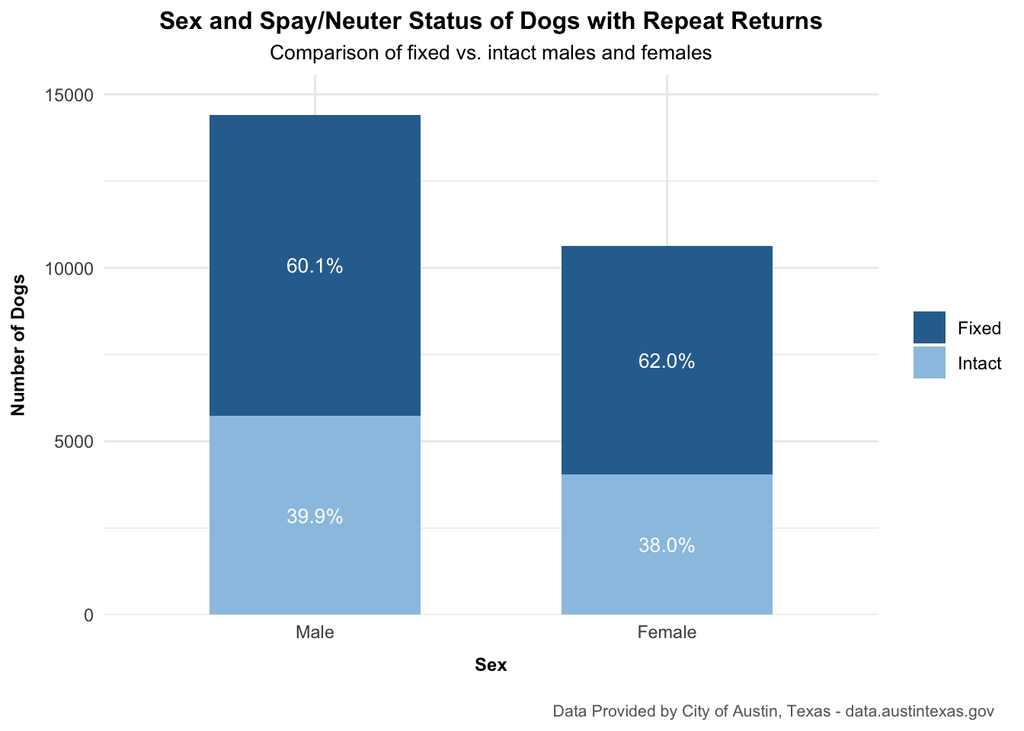

Source: Data Provided by City of Austin, Texas - data.austintexas.gov

```r
dog_repeat_sex |>
  ggplot(aes(x = SexSimple, y = n, fill = FixStatus)) +
  geom_col(width = 0.6) +
  geom_text(aes(label = label),
    position = position_stack(vjust = 0.5),
    color = "white", size = 3.5
  ) +
  scale_fill_manual(values = c(
    "Fixed" = "#2E6F9E",
    "Intact" = "#9BC4E2"
  )) +
  scale_y_continuous(expand = expansion(mult = c(0, 0.08))) +
  labs(
    title = "Sex and Spay/Neuter Status of Dogs with Repeat Returns",
    subtitle = "Comparison of fixed vs. intact males and females",
    x = "Sex",
    y = "Number of Dogs",
    caption = "Data Provided by City of Austin, Texas - data.austintexas.gov"
  ) +
  theme_minimal() +
  theme(
    legend.title = element_blank(),
    plot.title = element_text(hjust = 0.5, face = "bold", size = 12),
    plot.subtitle = element_text(hjust = 0.5, size = 10),
    axis.title.x = element_text(
      margin = margin(t = 8), face = "bold", size = 9
    ),
    axis.title.y = element_text(
      margin = margin(r = 8), face = "bold", size = 9
    ),
    plot.caption = element_text(
      hjust = 1.35,
      size = 8,
      color = "gray40",
      margin = margin(t = 15)
    ),
  )
```

### 4. Sex Distribution Within the Top 10 Repeat-Return Breeds

In the last section, we saw that most repeat-return dogs were already spayed or neutered, which challenges the idea that intact males are driving the pattern. So the next question is: within the breeds most likely to come back, does one sex tip the scales?

The one outlier was Staffordshire Mixes, where females actually made up the majority of returns. That tells us sex does play some role, but it’s not a one-size-fits-all story. It’s probably shaped by a mix of breed behavior patterns, adoption preferences, and the general population of dogs coming through the shelter.

With the “who” questions in mind, I then turned to the “when”, looking at whether certain seasons or historical shifts shaped the timing of these returns.

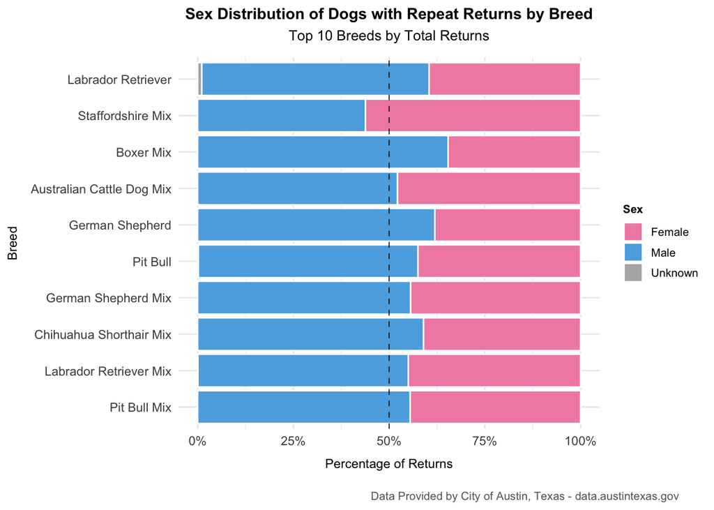

Data Provided by City of Austin, Texas - data.austintexas.gov

```r
# Filter for returned dogs only
returned_dogs <- aac_stays |>
  filter(species == "Dog", !is.na(sex_at_outcome), stay_n > 1)

# Simplify sex into Male / Female / Unknown
returned_dogs <- returned_dogs |>
  mutate(sex_grouped = case_when(
    str_detect(sex_at_outcome, "Male") ~ "Male",
    str_detect(sex_at_outcome, "Female") ~ "Female",
    TRUE ~ "Unknown"
  ))

# Get top 10 breeds
top_breeds <- returned_dogs |>
  count(breed_in, name = "total") |>
  arrange(desc(total)) |>
  slice_head(n = 10) |>
  pull(breed_in)

# Filter again to top breeds
filtered <- returned_dogs |>
  filter(breed_in %in% top_breeds)

# Create a stacked bar plot
ggplot(filtered, aes(x = fct_infreq(breed_in), fill = sex_grouped)) +
  geom_bar(position = "fill", color = "white", linewidth = 0.5) +
  coord_flip() +
  geom_hline(
    yintercept = 0.5, linetype = "dashed", color = "black",
    linewidth = 0.3
  ) + # Add line at 50%
  scale_y_continuous(labels = scales::percent_format()) +
  labs(
    title = "Sex Distribution of Dogs with Repeat Returns by Breed",
    subtitle = "Top 10 Breeds by Total Returns",
    x = "Breed",
    y = "Percentage of Returns",
    fill = "Sex",
    caption = "Data Provided by City of Austin, Texas - data.austintexas.gov"
  ) +
  scale_fill_manual(values = c(
    "Female" = "#F28DB2", "Male" = "#5DADE2",
    "Unknown" = "grey70"
  )) +
  theme_minimal() +
  theme(
    plot.title = element_text(hjust = 0.5, face = "bold", size = 11),
    plot.subtitle = element_text(
      hjust = 0.5, margin = margin(b = 10),
      size = 10
    ),
    axis.title.x = element_text(margin = margin(t = 8), size = 9),
    axis.title.y = element_text(margin = margin(r = 8), size = 9),
    plot.caption = element_text(
      hjust = 1.7,
      size = 8,
      color = "gray40",
      margin = margin(t = 15)
    ),
    legend.title = element_text(face = "bold", size = 8),
    legend.text = element_text(size = 8),
    legend.key.size = unit(1, "lines"),
    legend.spacing.y = unit(0.5, "cm")
  )
```

```r
# Takes a look at the raw numbers for evaluating males vs females ratio
returned_dogs |>
  filter(stay_n > 1) |>
  count(breed_in, sex_grouped) |>
  arrange(desc(n))
```

```
# A tibble: 1,353 × 3
   breed_in                sex_grouped     n
   <chr>                   <chr>       <int>
 1 Pit Bull Mix            Male         1286
 2 Pit Bull Mix            Female       1032
 3 Labrador Retriever Mix  Male          753
 4 Labrador Retriever Mix  Female        617
 5 Chihuahua Shorthair Mix Male          431
 6 German Shepherd Mix     Male          358
 7 Pit Bull                Male          305
 8 Chihuahua Shorthair Mix Female        300
 9 German Shepherd Mix     Female        286
10 Pit Bull                Female        226
# ℹ 1,343 more rows
```

### 5. Monthly Repeat Dog Intakes at Austin Animal Center

This heatmap tracks how many repeat-intake dogs came into the Austin Animal Center each month from 2014 through 2024. (I omitted both 2013 and 2025 because of incomplete data).

How to read this chart:

- Each row is a year; each column is a month.
- Darker shades mean fewer repeat intakes; lighter, hotter shades mean more.
- Look for horizontal bands (seasonal patterns) or sudden shifts (events or disruptions).

In 2020, the pattern broke sharply: repeat intakes dropped across nearly every month. This coincides with the COVID-19 pandemic, when shutdowns, higher adoption rates, and expanded fostering programs kept many dogs out of the shelter.

This monthly view highlighted two things clearly: consistent pre-pandemic peaks and a dramatic COVID-era dip. But one finding kept resurfacing in earlier analyses: neutered males consistently make up the largest share of repeat intakes. That made them worth a closer look.

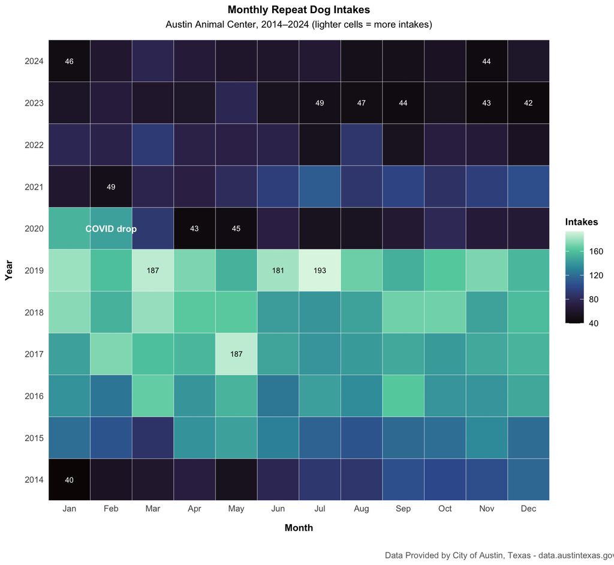

Data Provided by City of Austin, Texas - data.austintexas.gov

```r
# Prep ---------------------------------------------------------------

monthly_totals <- returned_dogs |>
  mutate(
    date_intake = as_date(datetime_intake),
    year  = year(date_intake),
    month = month(date_intake, label = TRUE)
  ) |>
  count(year, month)

# keep full years only
monthly_totals_clean <- monthly_totals |>
  filter(year >= 2014, year <= 2024, !is.na(month))

# y-position of the 2020 row (because y is a factor)
year_levels <- levels(factor(monthly_totals_clean$year))
covid_y     <- which(year_levels == "2020")

# Add a dynamic text color column
monthly_totals_clean <- monthly_totals_clean |>
  mutate(
    label_color = ifelse(n > 120, "black", "white") # adjust cutoff as needed
  )

# Heatmap with dynamic label colors
ggplot(monthly_totals_clean, aes(x = month, y = factor(year), fill = n)) +
  geom_tile(color = "white") +
  scale_x_discrete(expand = c(0, 0)) +
  scale_y_discrete(expand = c(0, 0)) +
  geom_text(aes(
    label = ifelse(n > 180 | n < 50, n, ""), color = label_color
  ), size = 2.5) +
  scale_color_identity() + # makes geom_text respect your label_color column
  scale_fill_viridis_c(name = "Intakes", option = "mako") +
  labs(
    title = "Monthly Repeat Dog Intakes",
    subtitle = "Austin Animal Center, 2014–2024 (lighter cells = more intakes)",
    x = "Month",
    y = "Year",
    caption = "Data Provided by City of Austin, Texas - data.austintexas.gov"
  ) +
  annotate("text",
    x = 2, y = 7, label = "COVID drop",
    color = "white", size = 3, fontface = "bold"
  ) +
  theme_minimal(base_size = 10) +
  theme(
    plot.title = element_text(hjust = 0.5, face = "bold", size = 10),
    plot.subtitle = element_text(
      hjust = 0.5, margin = margin(b = 10), size = 9
    ),
    axis.title.x = element_text(
      margin = margin(t = 10), face = "bold", size = 9
    ),
    axis.title.y = element_text(
      margin = margin(r = 10), face = "bold", size = 9
    ),
    plot.caption = element_text(
      size = 8, hjust = 1.25, margin = margin(t = 18), color = "gray40"
    ),
    legend.title = element_text(size = 9, face = "bold"),
    legend.text = element_text(size = 8)
  )
```

## Part 2: Neutered Males

In Part 1, we saw that male dogs make up a bigger share of repeat returns than females, and most of them were already neutered. That alone challenges the stereotype that intact males are the main culprits behind repeat visits. To dig deeper, I looked at how these neutered males were coming back to the shelter.

### 1. Why Neutered Males Return Multiple Times

**Owner-driven returns** stood out as the single biggest factor. Almost half (47.4%) of repeat intakes for neutered males were **owner surrenders**, cases where the owner brought the dog back themselves. The data doesn’t give exact reasons, but it likely includes things like housing restrictions, financial struggles, changes in family circumstances, or behavior issues that proved too much to handle.

**Stray intakes** made up another 39.6% of cases, where neutered males were picked up roaming and returned by a member of the public. A smaller share (12.3%) came in through “public assist” cases, where animal control or another city agency had to step in. The last 0.8% fell into “other” categories too uncommon to analyze.

Taken together, the numbers show that neutered males aren’t just escape artists, they’re often repeat visitors because of their owners’ circumstances or decisions. Without detailed “intake subtypes” we can’t know the exact why, but the categories point more toward human factors than the dogs themselves.

```r
# Creates a summary table of intake type counts and their proportions
neutered_males_summary <- dog_repeat |>
  filter(sex_upon_intake == "Neutered Male") |>
  mutate(
    intake_type = if_else(is.na(intake_type), "Unknown", intake_type),
    intake_type = case_when(
      intake_type %in% c(
        "Abandoned",
        "Euthanasia Request",
        "Unknown"
      ) ~ "Other",
      TRUE ~ intake_type
    )
  ) |>
  count(intake_type, name = "n") |>
  mutate(
    pct = n / sum(n),
    label = paste0(percent(pct, accuracy = 0.1), " (n=", comma(n), ")")
  ) |>
  arrange(pct)

# Review the summary table
neutered_males_summary
```

```
# A tibble: 4 × 4
  intake_type         n     pct label
  <chr>           <int>   <dbl> <chr>
1 Other              66 0.00761 0.8% (n=66)
2 Public Assist    1062 0.123   12.3% (n=1,062)
3 Stray            3431 0.396   39.6% (n=3,431)
4 Owner Surrender  4109 0.474   47.4% (n=4,109)
```

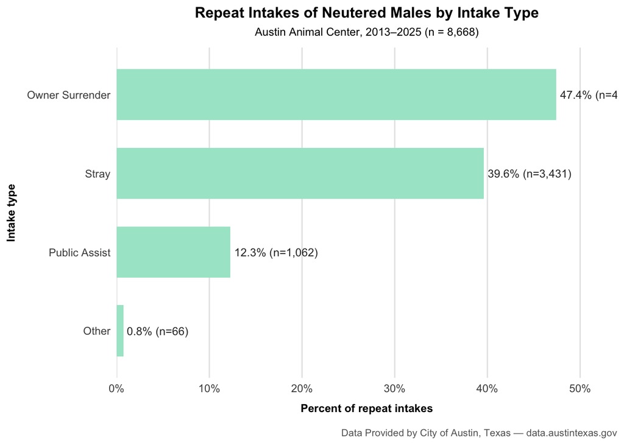

Data Provided by City of Austin, Texas — data.austintexas.gov

```r
# total N for subtitle (prevents error in Quarto rendering)
n_total <- sum(neutered_males_summary$n, na.rm = TRUE)

# Creates bar plot showing the counts for each type of intake
plot_df <- neutered_males_summary |>
  dplyr::arrange(dplyr::desc(pct)) |>
  dplyr::mutate(intake_type = forcats::fct_reorder(intake_type, pct))

ggplot(plot_df, aes(x = pct, y = intake_type)) +
  geom_col(fill = "#A8E6CF", width = 0.65) +
  geom_text(aes(label = label), hjust = -0.05, size = 3.2, color = "gray20") +
  scale_x_continuous(
    labels = scales::percent_format(accuracy = 1),
    limits = c(0, 0.50),
    breaks = seq(0, 0.50, by = 0.10),
    expand = expansion(mult = c(0, 0.08))
  ) +
  labs(
    title = "Repeat Intakes of Neutered Males by Intake Type",
    subtitle = paste0(
      "Austin Animal Center, 2013–2025 (n = ",
      scales::comma(n_total), ")"
    ),
    x = "Percent of repeat intakes",
    y = "Intake type",
    caption = "Data Provided by City of Austin, Texas — data.austintexas.gov"
  ) +
  theme_minimal(base_size = 11) +
  theme(
    panel.grid.major.y = element_blank(),
    panel.grid.major.x = element_line(color = "gray90"),
    panel.grid.minor = element_blank(),
    plot.title = element_text(hjust = 0.5, face = "bold", size = 12),
    plot.subtitle = element_text(
      hjust = 0.5, size = 9, margin = margin(b = 8)
    ),
    axis.title.x = element_text(
      margin = margin(t = 8), face = "bold", size = 9
    ),
    axis.title.y = element_text(
      margin = margin(r = 8), face = "bold", size = 9
    ),
    plot.caption = element_text(
      size = 8, color = "gray40", hjust = 1, margin = margin(t = 12)
    )
  )
```

### 2. Where Neutered Male Dogs End Up After Returning to the Shelter

After flagging neutered males as the largest group of repeat-intake dogs, I looked at what happened each time they left the shelter.

Most dogs left the shelter alive, but not every story ended that way:

- Euthanasia: 1.7% (157 dogs), usually for behavioral or medical reasons.
- No Outcome Recorded: 0.5% (49 dogs).
- Died in Care: 0.1% (11 dogs).
- Died (Disposal): 0.04% (4 dogs).
- Missing: <0.01% (1 dog).

These numbers tell us the big picture, but outcomes often depend on how a dog came back, whether as an owner surrender, a stray, or through another path. So next, I broke outcomes down by intake type to see if the story changes depending on how the dog re-entered the system.

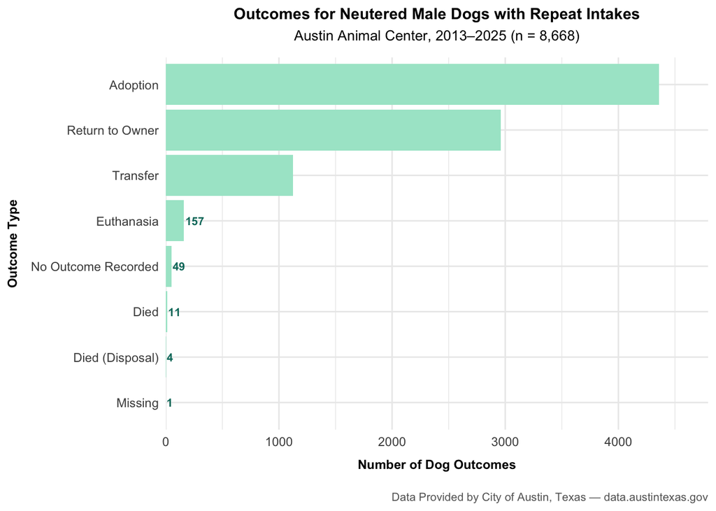

Data Provided by City of Austin, Texas — data.austintexas.gov

```r
# Create dataframe with only repeat intakes that are neutered males
repeat_neutered_males <- dog_repeat |>
  filter(sex_upon_intake == "Neutered Male")

# Recodes outcome types into easier to understand labels
repeat_neutered_males <- repeat_neutered_males |>
  mutate(outcome_type = case_when(
    outcome_type %in% c("Adoption", "Rto-Adopt") ~ "Adoption",
    outcome_type == "Return to Owner" ~ "Return to Owner",
    outcome_type == "Transfer" ~ "Transfer",
    outcome_type == "Euthanasia" ~ "Euthanasia",
    outcome_type == "Died" ~ "Died",
    outcome_type == "Disposal" ~ "Died (Disposal)",
    outcome_type == "Missing" ~ "Missing",
    is.na(outcome_type) ~ "No Outcome Recorded",
    TRUE ~ "Other"
  ))

# Recodes outcome subtypes into easier to understand labels
repeat_neutered_males <- repeat_neutered_males |>
  mutate(outcome_subtype = case_when(
    outcome_subtype %in% c("Medical", "Suffering") ~ "Medical/Suffering",
    outcome_subtype %in% c("Aggressive", "Behavior") ~ "Behavior/Aggression",
    outcome_subtype == "Partner" ~ "Transfer – Partner",
    outcome_subtype == "Foster" ~ "Foster Placement",
    outcome_subtype == "Offsite" ~ "Offsite Event",
    outcome_subtype == "Field" ~ "Field Outcome",
    outcome_subtype == "Court/Investigation" ~ "Court or Investigation",
    outcome_subtype == "Rabies Risk" ~ "Rabies Risk",
    outcome_subtype == "Out State" ~ "Out-of-State Transfer",
    outcome_subtype %in% c("In Foster", "In Kennel") ~ "In Care",
    outcome_subtype == "Prc" ~ "Partner Rescue Coordination",
    outcome_subtype == "At Vet" ~ "At Veterinary Partner",
    outcome_subtype == "Possible Theft" ~ "Possible Theft",
    outcome_subtype == "Emergency" ~ "Emergency Outcome",
    is.na(outcome_subtype) ~ "No Subtype Recorded",
    TRUE ~ "Other"
  ))

# Get counts for each outcome type
repeat_nm_outcome <- repeat_neutered_males |>
  mutate(outcome_type = coalesce(outcome_type, "Other")) |>
  count(outcome_type, name = "n") |>
  arrange(n) |>
  mutate(outcome_type = factor(outcome_type, levels = outcome_type))

# Plot the breakdown of outcomes for repeat intakes
ggplot(repeat_nm_outcome, aes(x = n, y = outcome_type)) +
  geom_col(fill = "#A8E6CF") +
  geom_text(
    data = ~ dplyr::filter(.x, n <= 1000),
    aes(label = scales::comma(n)),
    hjust = -0.1,
    size = 2.8,
    fontface = "bold",
    color = "#00796B"
  ) +
  scale_x_continuous(expand = expansion(mult = c(0, 0.10))) +
  labs(
    title = "Outcomes for Neutered Male Dogs with Repeat Intakes",
    subtitle = paste0(
      "Austin Animal Center, 2013–2025 (n = ",
      scales::comma(n_total), ")"
    ),
    x = "Number of Dog Outcomes",
    y = "Outcome Type",
    caption = "Data Provided by City of Austin, Texas — data.austintexas.gov"
  ) +
  theme_minimal() +
  theme(
    plot.title = element_text(hjust = 0.5, face = "bold", size = 11),
    plot.subtitle = element_text(
      hjust = 0.5, margin = margin(b = 10),
      size = 10
    ),
    axis.title.x = element_text(
      margin = margin(t = 8), size = 9, face = "bold"
    ),
    axis.title.y = element_text(
      margin = margin(r = 8), size = 9, face = "bold"
    ),
    plot.caption = element_text(
      hjust = 1, size = 8, color = "gray40",
      margin = margin(t = 15)
    )
  )
```

### 3. What’s behind the negative outcomes?

Breaking outcomes into subtypes gives us a sharper picture.

- **Transfers:** Nearly all went to partner rescues (95.6%, or 1,076 dogs), with a smaller share to out-of-state partners (4.4%, or 50 dogs).
- **Foster:** 589 dogs were placed in foster homes, often a stepping stone toward adoption.
- **Euthanasia:** The majority were for behavioral or aggression-related reasons (103 cases, 65.6%). Another 32 cases (20.4%) were due to medical issues or suffering.

```r
repeat_nm_subtype <- repeat_neutered_males |>
  mutate(outcome_subtype = coalesce(outcome_subtype, "Other")) |>
  count(outcome_subtype, name = "n") |>
  arrange(desc(n)) |>
  mutate(outcome_subtype = factor(outcome_subtype, levels = outcome_subtype))

repeat_nm_subtype
```

```
# A tibble: 15 × 2
   outcome_subtype                 n
   <fct>                       <int>
 1 No Subtype Recorded          6722
 2 Transfer – Partner           1076
 3 Foster Placement              589
 4 Behavior/Aggression           103
 5 Out-of-State Transfer          50
 6 Field Outcome                  36
 7 Medical/Suffering              32
 8 Offsite Event                  25
 9 Court or Investigation         10
10 In Care                        10
11 Rabies Risk                    10
12 At Veterinary Partner           2
13 Emergency Outcome               1
14 Partner Rescue Coordination     1
15 Possible Theft                  1
```

```r
# Filter for negative outcomes only
negative_patterns <- repeat_neutered_males |>
  filter(outcome_type %in% c("Euthanasia", "Died", "Missing", "No Outcome")) |>
  group_by(outcome_type, outcome_subtype) |>
  summarise(count = n(), .groups = "drop") |>
  arrange(desc(count))

# View the table
negative_patterns
```

```
# A tibble: 9 × 3
  outcome_type outcome_subtype        count
  <chr>        <chr>                  <int>
1 Euthanasia   Behavior/Aggression      103
2 Euthanasia   Medical/Suffering         32
3 Died         In Care                   10
4 Euthanasia   Court or Investigation    10
5 Euthanasia   Rabies Risk                9
6 Euthanasia   At Veterinary Partner      2
7 Died         Emergency Outcome          1
8 Euthanasia   No Subtype Recorded        1
9 Missing      Possible Theft             1
```

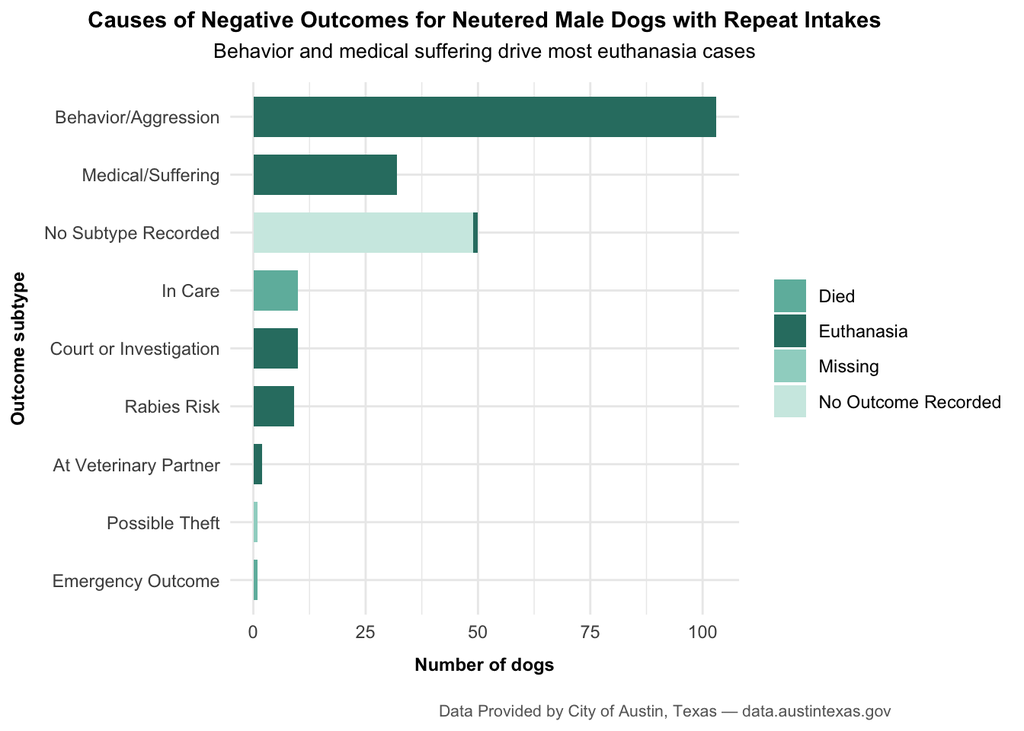

Data Provided by City of Austin, Texas – data.austintexas.gov

```r
# Creates list of levels to use for filter
neg_levels <- c("Euthanasia", "Died", "Missing", "No Outcome Recorded")

# Creates dataframe cross-tabbing outcome types and subtypes counts
negative_patterns <- repeat_neutered_males |>
  dplyr::filter(outcome_type %in% neg_levels) |>
  dplyr::count(outcome_type, outcome_subtype, name = "n") |>
  dplyr::arrange(desc(n)) |>
  dplyr::mutate(outcome_subtype = forcats::fct_reorder(outcome_subtype, n))

# Creates a Horizontal bar chart of cross tabs
ggplot(
  negative_patterns,
  aes(x = n, y = outcome_subtype, fill = outcome_type)
) +
  geom_col(width = 0.7) +
  scale_fill_manual(values = c(
    "Euthanasia" = "#2e7d71",
    "Died" = "#6fb9ab",
    "Missing" = "#9fd4ca",
    "No Outcome Recorded" = "#cfeae4"
  )) +
  labs(
    title =
      "Causes of Negative Outcomes for Neutered Male Dogs with Repeat Intakes",
    subtitle =
      "Behavior and medical suffering drive most euthanasia cases",
    x = "Number of dogs",
    y = "Outcome subtype",
    fill = "Outcome type",
    caption = "Data Provided by City of Austin, Texas — data.austintexas.gov"
  ) +
  theme_minimal(base_size = 11) +
  theme(
    plot.title = element_text(hjust = 0.5, face = "bold", size = 11),
    plot.subtitle = element_text(
      hjust = 0.5, margin = margin(b = 10),
      size = 10
    ),
    axis.title.x = element_text(
      margin = margin(t = 8), size = 9, face = "bold"
    ),
    axis.title.y = element_text(
      margin = margin(r = 8), size = 9, face = "bold"
    ),
    plot.caption = element_text(
      hjust = 3.7, size = 8, color = "gray40",
      margin = margin(t = 15)
    ),
    legend.title = element_blank()
  )
```

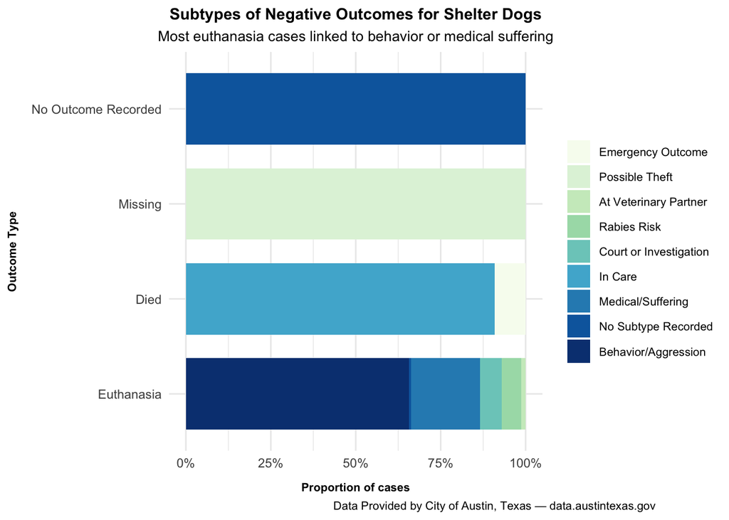

Data Provided by City of Austin, Texas - data.austintexas.gov

```r
# Define the outcome types to include
neg_levels <- c("Euthanasia", "Died", "Missing", "No Outcome Recorded")

# Summarize and compute proportions within each outcome_type
neg_props <- repeat_neutered_males |>
  filter(outcome_type %in% neg_levels, !is.na(outcome_subtype)) |>
  count(outcome_type, outcome_subtype, name = "n") |>
  group_by(outcome_type) |>
  mutate(prop = n / sum(n)) |>
  ungroup() |>
  mutate(outcome_type = factor(outcome_type, levels = neg_levels)) |>
  mutate(outcome_subtype = fct_reorder(outcome_subtype, n, .fun = sum))

# Creates stacked bar plot
ggplot(
  neg_props,
  aes(x = outcome_type, y = prop, fill = outcome_subtype)
) +
  geom_col(width = 0.75, color = NA) +
  coord_flip() +
  scale_y_continuous(labels = scales::percent) +
  scale_fill_brewer(palette = "GnBu") + # auto pastel palette
  labs(
    title = "Subtypes of Negative Outcomes for Shelter Dogs",
    subtitle = "Most euthanasia cases linked to behavior or medical suffering",
    x = "Outcome Type",
    y = "Proportion of cases",
    fill = "Outcome subtype",
    caption = "Data Provided by City of Austin, Texas — data.austintexas.gov"
  ) +
  theme_minimal(base_size = 11) +
  theme(
    plot.title = element_text(hjust = 0.5, size = 11, face = "bold"),
    plot.subtitle = element_text(hjust = 0.5, size = 10),
    axis.title.x = element_text(
      margin = margin(t = 9), face = "bold", size = 8
    ),
    axis.title.y = element_text(
      margin = margin(r = 9), face = "bold", size = 8
    ),
    legend.position = "right",
    legend.title = element_blank(),
    legend.text = element_text(size = 8),
    plot.caption = element_text(hjust = 3.2, size = 8)
  )
```

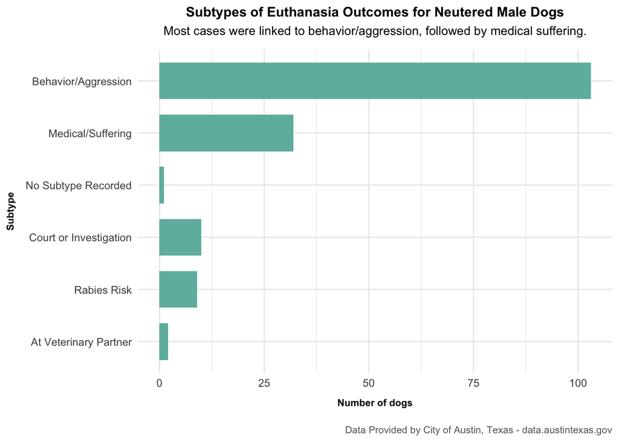

Data Provided by City of Austin, Texas - data.austintexas.gov

```r
#|

# Creates simple count bar plot of euthanasia subtypes
negative_patterns |>
  dplyr::filter(outcome_type == "Euthanasia") |>
  ggplot(aes(n, outcome_subtype)) +
  geom_col(fill = "#6fb9ab", width = 0.7) +
  labs(
    title = "Subtypes of Euthanasia Outcomes for Neutered Male Dogs",
    subtitle =
      paste0("Most cases were linked to behavior/aggression, ",
      "followed by medical suffering."),
    x = "Number of dogs",
    y = "Subtype",
    caption = "Data Provided by City of Austin, Texas - data.austintexas.gov"
  ) +
  theme_minimal(base_size = 11) +
  theme(
    plot.title = element_text(hjust = 0.5, face = "bold", size = 11),
    plot.subtitle = element_text(
      hjust = 0.5, margin = margin(b = 10), size = 10
    ),
    axis.title.x = element_text(
      margin = margin(t = 8), size = 8, face = "bold"
    ),
    axis.title.y = element_text(
      margin = margin(r = 8), size = 8, face = "bold"
    ),
    plot.caption = element_text(
      hjust = 1, size = 8, color = "gray40",
      margin = margin(t = 15)
    )
  )
```

### 4. Outcomes by Intake Reason: Neutered Males

This chart compares what happened to neutered male dogs after returning to the shelter, split into two groups: owner surrenders and non–owner surrenders (strays or public assist).

- **Owner Surrenders:** Most were rehomed (74.3% were adopted). Transfers made up 18.7%, while just 4.0% were reunited with their original owner. Euthanasia occurred in 2.0%.
- **Non–Owner Surrenders:** The majority (61.4%) were reclaimed by their families. Adoption followed at 28.6%, then transfers at 7.8%. Euthanasia occurred in 1.6%.

Owner-surrendered dogs tend to move on through adoption, while non–owner surrenders are most often reunited with their original families. In both groups, euthanasia remains rare but slightly more frequent among owner surrenders.

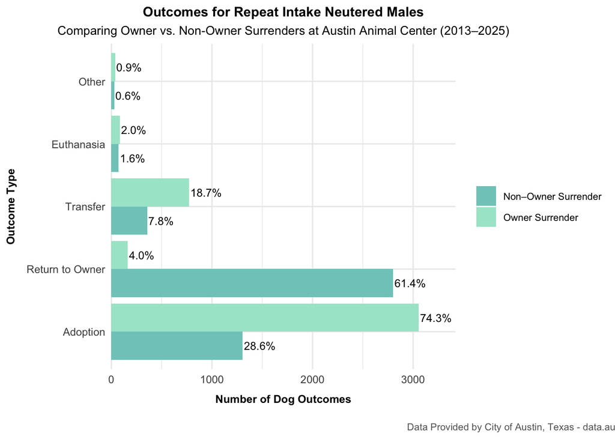

Source: Data Provided by City of Austin, Texas - data.austintexas.gov

```r
# Build the raw comparison table (before collapsing)
cmp_nm_raw <- repeat_neutered_males |>
  mutate(
    intake_group = if_else(intake_type == "Owner Surrender",
      "Owner Surrender", "Non–Owner Surrender"
    ),
    outcome_type = coalesce(outcome_type, "No Outcome Recorded")
  ) |>
  count(intake_group, outcome_type, name = "n")

# Collapse tiny outcomes into "Other" and recompute percents
others_vec <- c(
  "Missing", "Died (Disposal)", "Died",
  "No Outcome Recorded", "Died / No Outcome Recorded"
)

cmp_nm <- cmp_nm_raw |>
  mutate(outcome_type = if_else(outcome_type %in% others_vec, "Other",
    outcome_type
  )) |>
  group_by(intake_group, outcome_type) |>
  summarise(n = sum(n), .groups = "drop") |>
  group_by(intake_group) |>
  mutate(
    pct   = n / sum(n),
    label = scales::percent(pct, accuracy = 0.1)
  ) |>
  ungroup() |>
  mutate(
    outcome_type = factor(outcome_type,
      levels = c(
        "Adoption", "Return to Owner", "Transfer", "Euthanasia",
        "Other"
      )
    )
  )

# Creates Side-by-side bar chart (counts on the x-axis; percent labels on bars)
ggplot(cmp_nm, aes(x = n, y = outcome_type, fill = intake_group)) +
  geom_col(position = position_dodge(width = 0.9)) +
  geom_text(aes(label = label),
    position = position_dodge(width = 0.9),
    hjust = -0.05, size = 3.2
  ) +
  scale_x_continuous(expand = expansion(mult = c(0, 0.12))) +
  scale_fill_manual(
    values = c(
      "Owner Surrender"     = "#A8E6CF",
      "Non–Owner Surrender" = "#80CBC4"
    )
  ) +
  labs(
    title = "Outcomes for Repeat Intake Neutered Males",
    subtitle = paste(
    "Comparing Owner vs. Non-Owner Surrenders at Austin Animal Center",
    "(2013–2025)"),
    x = "Number of Dog Outcomes",
    y = "Outcome Type",
    caption =
      "Data Provided by City of Austin, Texas - data.austintexas.gov",
    fill = NULL
  ) +
  coord_cartesian(clip = "off") +
  theme_minimal(base_size = 11) +
  theme(
    plot.title = element_text(hjust = 0.5, size = 11, face = "bold"),
    plot.subtitle = element_text(hjust = 0.5, size = 10),
    axis.title.x = element_text(
      margin = margin(t = 8), size = 9, face = "bold"
    ),
    axis.title.y = element_text(
      margin = margin(r = 8), size = 9, face = "bold"
    ),
    plot.caption = element_text(
      hjust = 3.75, size = 8, color = "gray40",
      margin = margin(t = 15)
    ),
    legend.position = "right",
    legend.text = element_text(size = 8)
  )
```

```r
# Creates transparency table: what’s inside "Other" (by intake group)
other_breakdown <- cmp_nm_raw |>
  filter(outcome_type %in% others_vec) |>
  arrange(intake_group, outcome_type)

other_breakdown
```

```
# A tibble: 6 × 3
  intake_group        outcome_type            n
  <chr>               <chr>               <int>
1 Non–Owner Surrender Died                    3
2 Non–Owner Surrender Died (Disposal)         4
3 Non–Owner Surrender No Outcome Recorded    21
4 Owner Surrender     Died                    8
5 Owner Surrender     Missing                 1
6 Owner Surrender     No Outcome Recorded    28
```

### 5. Most Common Breeds in Repeat Neutered Male Dog Intakes

After looking at outcomes, the next question is which breeds dominate this group of repeat-intake neutered males.

This skew matters because when one or two breeds dominate, their outcomes shape the overall picture. If Pit Bulls are returned more often, then their adoption, transfer, or euthanasia rates weigh heavily on the shelter’s statistics. It also raises the possibility that breed-specific barriers, like housing restrictions, behavioral expectations, or adopter mismatches, are at play.

This means that the over representation of a few breeds means that targeted adoption counseling, breed-specific support, or community education could make a measurable impact on reducing repeat returns.

[figure not shown]

Source: Data Provided by City of Austin, Texas - data.austintexas.gov

```r
# Count visits per neutered male (per dog & breed), keep repeat visitors only
visits_per_nm <- repeat_neutered_males |>
  group_by(animal_id, breed_in) |>
  summarise(total_visits = n(), .groups = "drop") |>
  filter(total_visits > 1)

# Finds top breeds by number of distinct dogs (among repeat neutered males)
top_breeds_neutered_males <- visits_per_nm |>
  group_by(breed_in) |>
  summarise(dog_count = n_distinct(animal_id), .groups = "drop") |>
  arrange(desc(dog_count))

# Plots top 10 breeds
top_breeds_neutered_males |>
  slice_max(order_by = dog_count, n = 10) |>
  ggplot(aes(x = reorder(breed_in, dog_count), y = dog_count)) +
  geom_col(fill = "#A8E6CF") +
  coord_flip() +
  labs(
    title = "Top Breeds of Repeat Neutered Males",
    subtitle = paste0("Pit Bull Mixes lead by a wide margin, nearly doubling",
                      "the next highest breed."),
    x = "Dog Breed",
    y = "Number of Dogs",
    caption =
      "Source: Data Provided by City of Austin, Texas - data.austintexas.gov"
  ) +
  theme_minimal(base_size = 12) +
  theme(
    plot.title = element_text(hjust = 0.5, face = "bold", size = 11),
    plot.subtitle = element_text(
      hjust = 0.5, margin = margin(b = 10),
      size = 9
    ),
    axis.title.x = element_text(
      margin = margin(t = 8), face = "bold",
      size = 9
    ),
    axis.title.y = element_text(
      margin = margin(r = 8), face = "bold",
      size = 9
    ),
    plot.caption = element_text(
      hjust = 1, size = 8, color = "gray40",
      margin = margin(t = 15)
    )
  )
```

# Conclusion & Implications

This analysis of repeat dog intakes at the Austin Animal Center shows that while most dogs return only once, a smaller but important subset (especially neutered males) cycle back multiple times. Breeds such as Pit Bull Mixes, Labrador Retriever Mixes, and Chihuahua Shorthair Mixes are disproportionately represented, which means their outcomes weigh heavily on the shelter’s overall trends. Intake reason also matters: owner surrenders are most often rehomed through adoption, while non–owner surrenders are more often reunited with their families. Seasonal peaks before 2020, the sharp pandemic drop, and slower rebounds afterward suggest that community behavior and shelter operations strongly shape return patterns.

## Critical Reflection

This project really challenged some of the usual assumptions about why dogs keep coming back to shelters. I honestly expected intact males to dominate the repeat-intake group, but the data showed something else entirely: neutered males actually made up the *largest* share. That shifted my perspective and made it clear that returns are often less about the dog’s biology and more about human factors like housing restrictions, financial struggles, or adopters feeling overwhelmed.

Linking intakes and outcomes at the individual dog level was another eye-opener. Instead of just seeing totals, I could actually follow dogs through multiple visits, which revealed patterns I wouldn’t have noticed otherwise. The biggest one was the split between owner surrenders and non-owner surrenders (owners bringing dogs back themselves vs. dogs being found as strays). That difference shaped outcomes in big ways.

Of course, the dataset had limits. The “owner surrender” category doesn’t tell us whether someone gave up their dog because of money, housing, or behavior. “Adoption” just tells us the dog left with someone new, not whether the placement stuck. Bigger context, like breed restrictions in housing or local eviction rates, is also missing, even though those things probably play a huge role. And because this is just one city shelter, the results can’t be applied to every type of shelter, especially limited-intake ones.

Working through these gaps made me think more about ethics in shelter data. It’s easy to point to breed patterns, but that can reinforce stereotypes if you don’t acknowledge the bigger picture of adopter bias, housing discrimination, and systemic barriers. It also matters that the dataset was de-identified, it’s less detail to work with but a necessary trade off to protect people’s privacy.

In the end, this project gave me stronger technical skills and a better sense of how messy real-world data connects to animal welfare. It also left me with new questions: how age affects repeat returns, how community-level issues like poverty and housing impact intakes, and what kinds of support actually help keep dogs in homes. Those are the kinds of things I’d want to dig into next, since they’d make future research more useful not just for shelters, but for adopters and especially for the sweet pups who end up back in the system.

# References

ASPCA. (2024). Pet statistics. ASPCA. https://www.aspca.org/helping-shelters-people-pets/us-animal-shelter-statistics

City of Austin, Texas. (2025). Austin Animal Center intake and outcome data (2013–2025) [Data set]. City of Austin Open Data Portal. https://data.austintexas.gov

Grolemund, G., & Wickham, H. (2017). R for data science: Import, tidy, transform, visualize, and model data. O’Reilly Media.

Hawes, S. M., Kerrigan, J. M., & Morris, K. N. (2020). Factors informing outcomes for older cats and dogs in animal shelters. Animals, 10(5), 746. https://doi.org/10.3390/ani10050746

Long, J. D. (2019). R cookbook: Proven recipes for data analysis, statistics, and graphics (2nd ed.). O’Reilly Media.

Miller, J. E. (2005). The Chicago guide to writing about multivariate analysis. University of Chicago Press.

Patronek, G. J., Glickman, L. T., Beck, A. M., McCabe, G. P., & Ecker, C. (1996). Risk factors for relinquishment of dogs to an animal shelter. Journal of the American Veterinary Medical Association, 209(3), 572–581. https://pubmed.ncbi.nlm.nih.gov/8755975/

R Core Team. (2025). R: A language and environment for statistical computing. R Foundation for Statistical Computing. https://www.R-project.org

# Appendix

## Data Source & Preparation Information

This appendix documents the main data cleaning and wrangling steps used to prepare the Austin Animal Center intake and outcome records for analysis. These details are included so that other data scientists can evaluate or replicate the approach.

**Data Source**

- [**Austin Animal Center Intake and Outcome Data (2013–2025)**](https://data.austintexas.gov/browse?q=animal&sortBy=relevance&page=1&pageSize=20), retrieved from the City of Austin Open Data Portal.
- Intake and outcome records were provided as separate tables and joined during preprocessing.

**Data Cleaning and Transformation**

1. Date Conversion
   - Intake and outcome datetime fields were converted to Date objects for easier aggregation
2. Stay Number Assignment
   - Because animals may enter the shelter multiple times, each visit was assigned a sequential stay number.
   - This ensured that outcomes were linked to the correct intake event.
3. Dataset Join
   - Intake and outcome datasets were joined using a combination of animal_id and stay_number
   - This created a single record per animal visit that included both intake context and outcome.
4. Species Filtering
   - The dataset was filtered to include dogs only, excluding cats and other animals.
5. Repeat Visitors
   - A repeat visitor indicator was created to flag animals with more than one intake.
   - Analyses in this project focused on dogs with repeat visits.
6. Variable Recoding
   - Intake Type was simplified into two categories:
     - Owner surrender • Non-owner surrender (stray, public assist, confiscation, etc.)
     - Outcome Type was grouped into broader categories for interpretability:
       - Adoption
       - Return to Owner
       - Transfer
       - Euthanasia
       - Other (missing, died in care, etc.)
7. Handling Missing or Ambiguous Data
   - Intake age was complete, so no imputation was required.
   - A small number of cases with missing outcome types were retained and coded as “No Outcome Recorded.”

**Tools Used**

The analysis was conducted in R (version 4.4.0) using the following packages:

- `dplyr` – data manipulation • tidyr – reshaping data (wide ↔︎ long)
- `lubridate` – working with dates/times • readr – reading CSV and other flat files
- `forcats` – handling categorical variables
- `stringr` – string/text operations
- `here` – managing file paths
- `janitor` – cleaning messy data
- `ggplot2` – data visualization
- `purrr` – functional programming and iteration
- `scales` – formatting axes, labels, and colors • patchwork – combining multiple plots
- `gt` – generating professional tables
- `ggrepel` – improved text labels on plots
- `grid` – fine-tuning plot layout
- `zoo` – rolling averages (e.g., rollmean())

## Data Wrangling (Full Code)

Below is the complete code used to clean, join, and prepare the data used in this report.

```r
# Libraries used
library(dplyr)      # data manipulation
library(tidyr)      # reshape data (wide ↔ long)
library(lubridate)  # work with dates/times
library(readr)      # read CSV and other flat files
library(forcats)    # handle categorical variables
library(stringr)    # string/text operations
library(here)       # manage file paths
library(janitor)    # clean messy data
library(ggplot2)    # create plots
library(purrr)      # functional programming / iteration
library(scales)     # format axes, labels, colors
library(patchwork)  # combine multiple plots
library(gt)         # make clean, professional tables
library(ggrepel)    # better text labels on plots
library(grid)       # fine-tune plot layout
library(zoo)        # rolling averages (e.g., rollmean())

# Read in the Austin Animal Center Animal Outcomes dataset.
aac_outcome <- read.csv(here("Data", "aac_outcomes.csv"))

# Clean up column names
aac_outcome <- aac_outcome |>
  clean_names() |>
  mutate(across(everything(), ~ na_if(.x, "")))

# Change date types for columns date_of_birth and date_time
# - Separate month_year to two separate month and year columns
aac_outcome <- aac_outcome |>
  mutate(
    date_of_birth = ymd(date_of_birth),
    date_time = ymd_hms(date_time),
    year = year(date_time),
    month = month(date_time)
  ) |>
  select(-month_year)
# Calculate true ages of animals ------------------------------------
# - separating into two columns for:
# -- age in years
# -- age in days
aac_outcome <- aac_outcome |>
  mutate(
    age_days = as.numeric(
      difftime(date_time, date_of_birth, units = "days")
    ),
    age_years = age_days / 365.25
  )

# Mark observations that have negative values for their ages
aac_outcome <- aac_outcome |>
  mutate(
    invalid_dob = if_else(date_of_birth > date_time, TRUE, FALSE),
    age_days = if_else(invalid_dob, NA_real_, age_days),
    age_years = if_else(invalid_dob, NA_real_, age_years)
  )

# Rename the column names for easier identification
aac_outcome <- aac_outcome |>
  rename(
    dob = date_of_birth,
    outcome_datetime = date_time,
    sex_at_outcome = sex_upon_outcome,
    reported_age = age_upon_outcome,
    species = animal_type,
    outcome_year = year,
    outcome_month = month,
    calculated_age_days = age_days,
    calculated_age_years = age_years,
    dob_error_flag = invalid_dob
  )
# Read in intake dataset
aac_intake <- read.csv(here("Data", "aac_intakes.csv"))

# Clean up column names
aac_intake <- aac_intake |>
  clean_names()

# Change date types for columns date_of_birth and date_time
# - Separate month_year to two seperate month and year columns
aac_intake <- aac_intake |>
  mutate(
    datetime_intake = mdy_hms(date_time),
    year_intake = year(datetime_intake),
    month_intake = month(datetime_intake)
  ) |>
  select(-month_year)
# Reported Age ----------------------------------------------------------
# - separate numeral and length type (years/months)
# - calculate age in days instead

# Builds a lookup table that converts each unit to days
age_lookup <- tibble(
  unit_raw = c(
    "day", "days",
    "week", "weeks",
    "month", "months",
    "year", "years"
  ),
  to_days = c(
    1, 1,
    7, 7,
    30.44, 30.44,
    365.25, 365.25
  )
)

# Parses the text column, joins the lookup, and calculates days
aac_intake <- aac_intake |>
  separate(age_upon_intake,
    into = c("age_val", "age_unit"),
    sep = "\\s+",
    remove = FALSE
  ) |>
  mutate(age_val = as.numeric(age_val)) |>
  left_join(age_lookup, by = c("age_unit" = "unit_raw")) |>
  mutate(
    age_days_intake = age_val * to_days,
    age_years_intake = age_days_intake / 365.25
  )
# Change missing names in name column from empty to NA
aac_intake <- aac_intake |>
  mutate(name = na_if(str_squish(name), ""))
# Tags each stay in date order for both intake and outcome dataframes
aac_intake <- aac_intake |>
  arrange(animal_id, datetime_intake) |>
  group_by(animal_id) |>
  mutate(stay_n = row_number()) |>
  ungroup()

aac_outcome <- aac_outcome |>
  arrange(animal_id, outcome_datetime) |>
  group_by(animal_id) |>
  mutate(stay_n = row_number()) |>
  ungroup()

# Joins the two columns by animal id and stay_n
aac_stays <- aac_intake |>
  left_join(aac_outcome,
    by = c("animal_id", "stay_n"),
    suffix = c("_in", "_out")
  )

# Create separate dataframe for just dogs
dogs <- aac_stays |>
  filter(animal_type %in% "Dog")

# Create a dataframe with a list of each animal-id and the number of total
# visits they've had
repeat_ids <- dogs |>
  group_by(animal_id) |>
  summarise(n_intakes = n(), .groups = "drop") |>
  filter(n_intakes > 1)

# Combine above dataframes to create one dataframe of only repeat dogs
dog_repeat <- dogs |>
  semi_join(repeat_ids, by = "animal_id")
```